# The Urban Ministries Project

[figure not shown]

##### Created by: Amber Young

## What is Urban Ministries?

Urban Ministries, established in 1983, offers many programs to help support homeless and low-income people in the Durham community. These programs include:

- A community shelter, which can accomodate over 140 people a night
- A community cafe, which offers breakfast, lunch, and dinner daily to the homeless
- A food pantry, that provides people with groceries, and
- A clothing closet, that supplies individuals and families with clothing each month.

All together this organization helps about 6,000 people per year with over 4,000 volunteers. They rely heavily on donations of food and clothing from the community.

## What questions will this project address?

Some challenges an organization like this faces is knowing “how much” and “when”. Having answers to these two questions can help them know when to collect donations, when to hold food/clothing drives, and even when they need to schedules volunteers. Therefore, this project seeks to help Urban Ministries understand the trends in their food and clothing distribution by answering questions such as:

- How much food and clothing do they need in supply to make it through a week?
- How much food and clothing can Urban ministries expect to distribute on any given day of the week?
- When can they expect to serve larger families who naturally need more resources?

## No Trends in Weekly Totals Throughout the Year

Looking at total pounds of food and number of clothes distributed by week of the year, there seems to be no distinct trend. This is actually surprising since one may expect Urban Ministries to distribute more clothes or food in weeks closer to christmas or other holidays. All weeks seem to have about the same average number of clothes and pounds of food distributed. We can see this in the following plots.

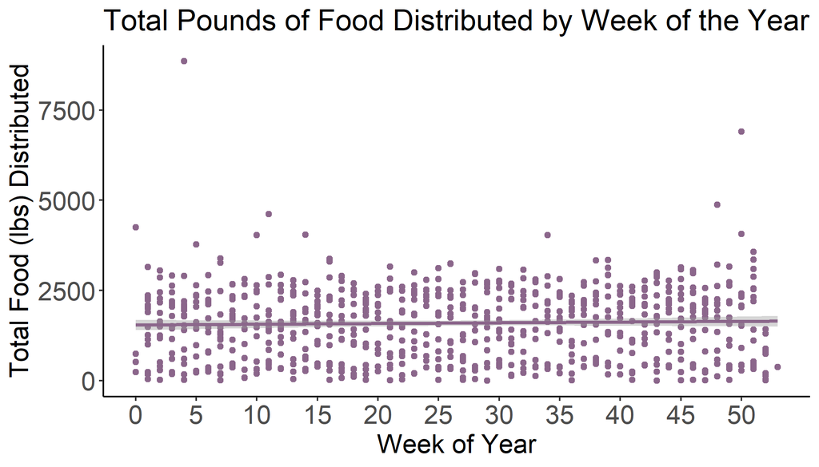

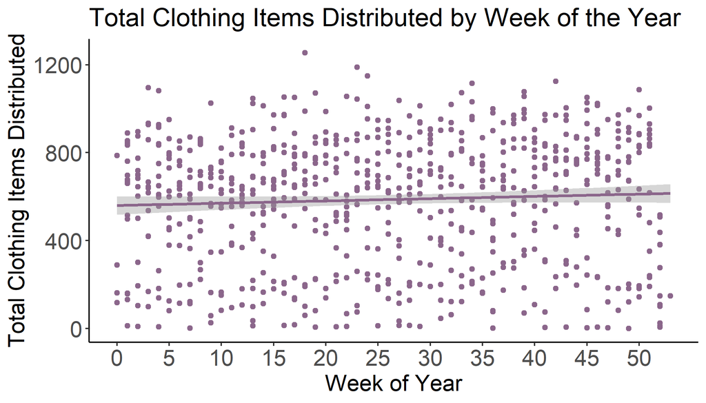

In these plots, the trend line is almost completely horizontal, which tells us that there is no change in clothing or food distributed by the week of the year. Therefore, the simplest way to know how much food or clothes Urban Ministries needs in a given week is just the averages.

## Average Food and Clothes Needed in a Week

The following table summarizes these results:

|  | Average | Lower Bound | Upper Bound |
| --- | --- | --- | --- |
| Pounds of Food | 1591 | 1496 | 1686 |
| Items of Clothing | 587 | 559 | 614 |

## The Friday Phenomenon

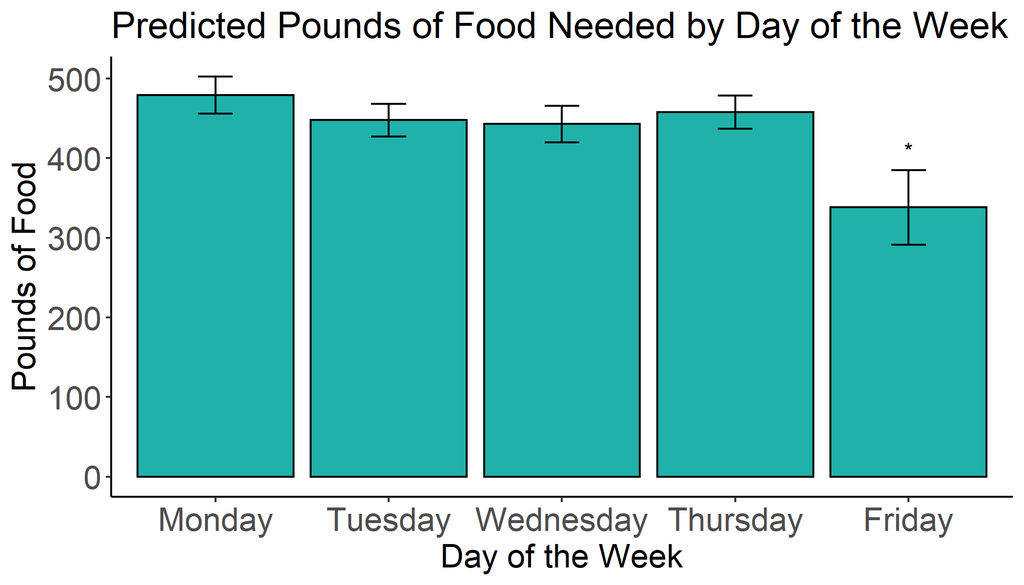

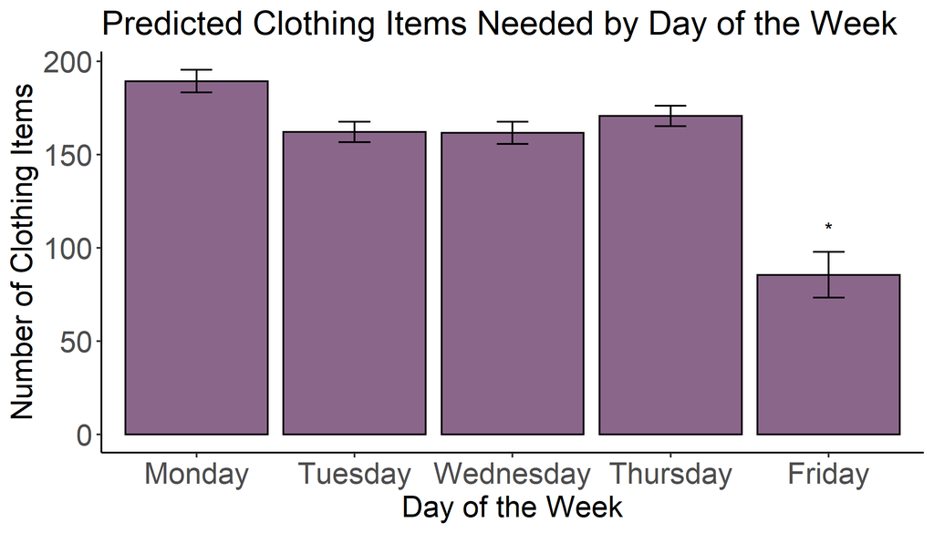

## Explaining the Friday Phenomenon

### Less Visitors on Friday

It turns out that, in general, we expect to see less families visit Urban Ministries on Friday. (A family is defined as 1 or more people.) We can clearly see this trend in the plot below.

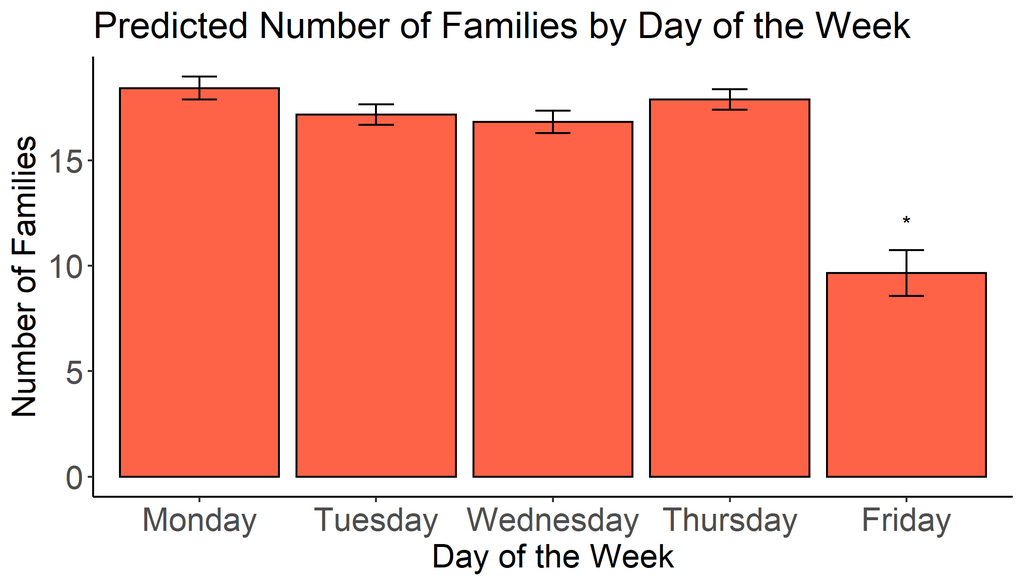

This could be a large contributer to why they distribute less food and clothing on Fridays. If less people are coming in, then it makes obvious sense that less product is going out. However, the question remains as to why they see less people on Fridays.

### History of almost no visitors on Friday

To answer the question of why there tends to be less visitors on Friday, we plot the average number of visitors by weekday split by year for the past 12 years.

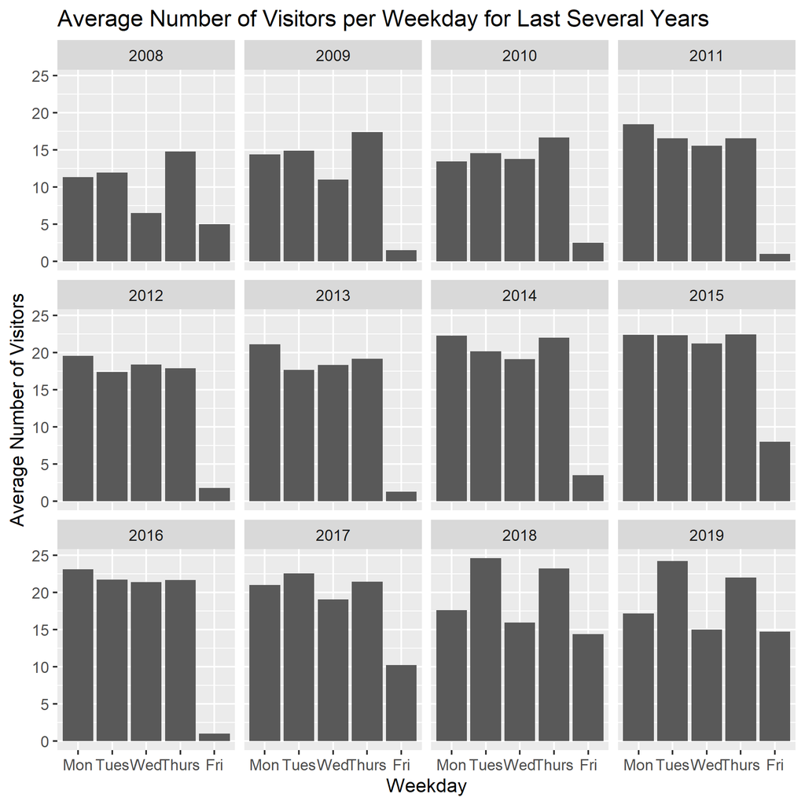

As we can see from this plot, there is far less people coming in on Fridays than any other day of the week until about 2017 or 2018. This trend suggests that perhaps there was a change in hours of operation at the ministry. Maybe they were only open on some Fridays, but not all, in the past. Either way, to better understand trends applicable to the present, it may be better to only look at 2018-2019 data when predicting on day of the week. Therefore, the following section better decscribes the trends they can expect on each day of the week.

## Predicted Number of Clothes and Pounds of Food Needed by Day of the Week

Restricting the data to only 2018 and 2019, we get the following predicted values for number of clothes and pounds of food.

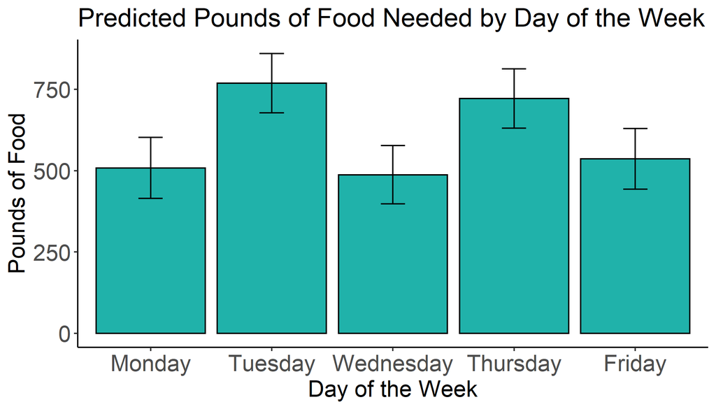

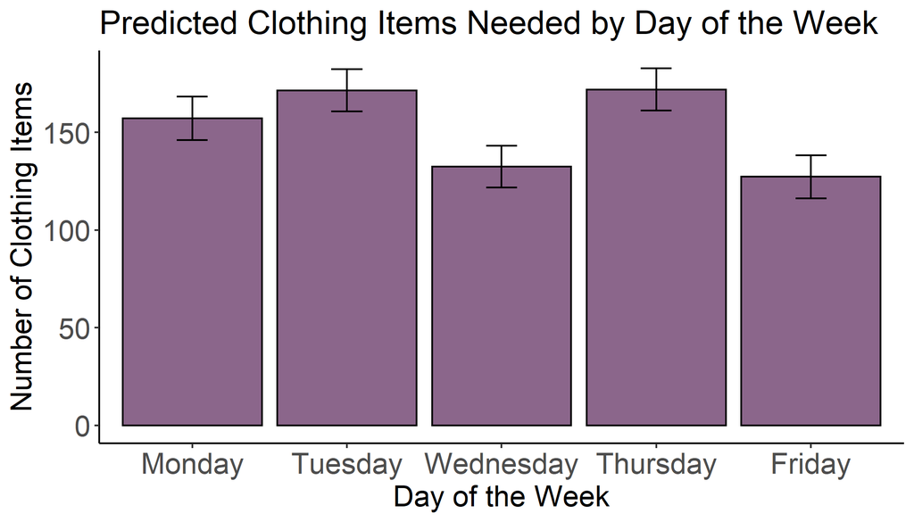

We can see that in both cases they tend to distribute more on Tuesdays and Thursdays than on MWF. This is actually reflective of their hours of operation. They are open for more hours on Tuesdays and Thursdays. While this is not so surprising, it is still useful for Urban Ministries to have the predicted values and confidence intervals.

## Large Families Need More Resources

Large families naturally need more of everything. Therefore, the amount of any product distributed is driven by the number of large families that visit that day. On a given day, the more large families that visit Urban Ministries, the more food or the clothing that will be distributed. We can easily see this in the following two graphs. (For this analysis, a large familiy is defined as greater than 5 people).

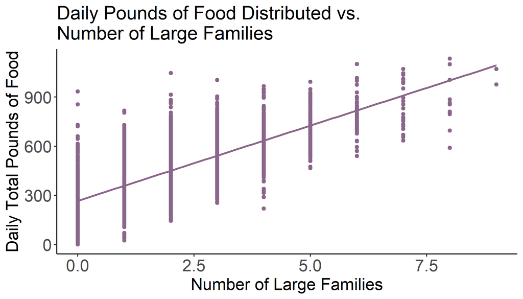

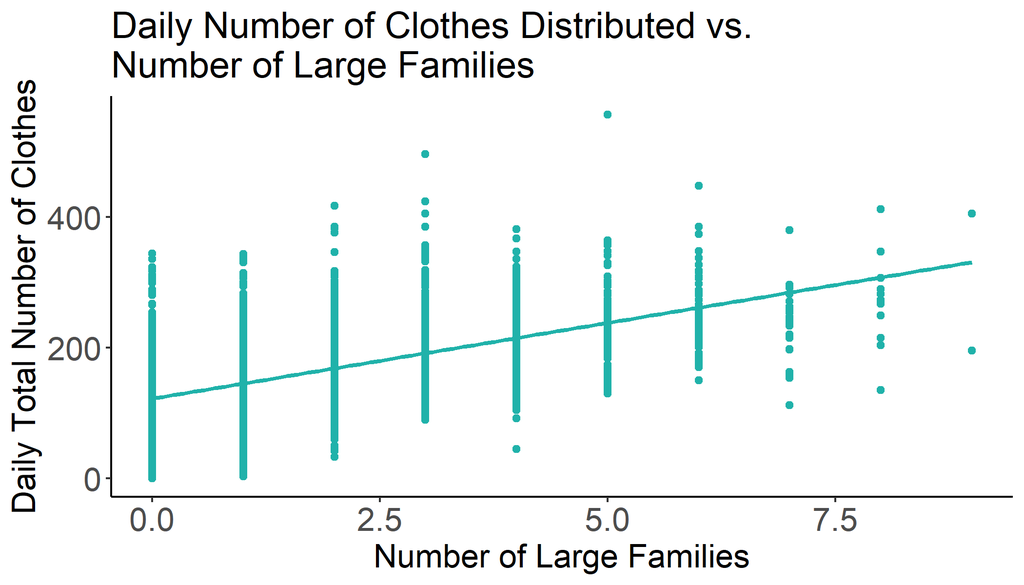

This next graph summarizes the relationship between all three variables, when there are more large families, there is more food and clothes distributed.

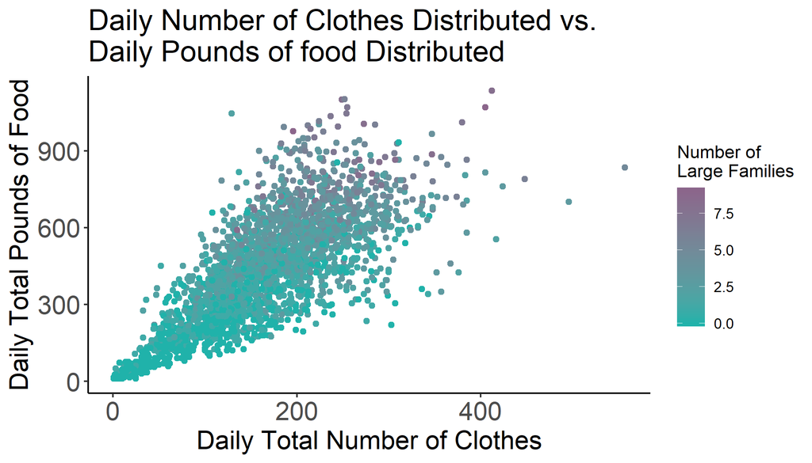

### More large families on Fridays

Since there is such a correlation between the number of large families that visit in a given day and the amount a resources the shelter provides on that day, knowing what days of the week will see a higher proportion of large families is particulary useful for Urban Ministries. The following plot summarizes the results of this analysis.

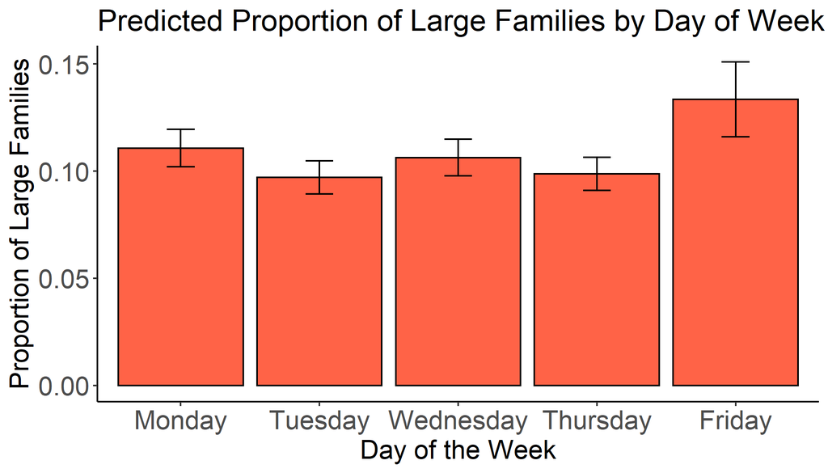

In this graph, we can see that we might expect the proportion of large families to be fairly consistent Monday through Thursday. On Friday, we can expect a slightly higher proportion of large families, with a wider confidence interval. Therefore, Urban Ministries may consider saving some extra resources for the end of the week.

## Conclusions

This report primarily provides Urban Ministries with tools for knowing “how much” and “when”. In general, the tables and graphs in this report can help them be better prepared for what to expect in a given week or on a given day. With this information, they can know when they are running low on items, and when they need to restock. This can help them know when to ask for additional donations, or hold food or clothing drives. Hopefully, these tools help Urban Ministries better serve the Durham community.